# Document

### 1.a) Write a python program to find the inverse of the following matrix.

$\begin{pmatrix} 3 & 5 & 8 \\ 4 & 6 & 9 \\ 8 & 6 & 4 \end{pmatrix}$

[Download this program](https://gribja.github.io/c5pQ2018/q1a.py)

```python
import numpy as np
A=np.array([[3,5,8],[4,6,9],[8,6,4]])
A_inv=np.linalg.inv(A)
print(A_inv)
```

```
[[ 15.  -14.    1.5]
 [-28.   26.   -2.5]
 [ 12.  -11.    1. ]]
```

### 1.b) Write a python program to solve the differential equation for radioactive decay using Euler method and plot it using Matplotlib module.

[Download this program](https://gribja.github.io/c5pQ2018/q1b.py)

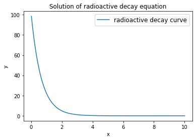

```python
import matplotlib.pyplot as plt
def f(x,y):
    return -lmbda*y
x,y,h=0,100,0.01
lmbda=1.50
X,Y=[],[]
n=0
while n<=1000:
    y+=h*f(x,y)
    x+=h
    X.append(x)
    Y.append(y)
    n+=1
plt.plot(X,Y,label='radioactive decay curve')
plt.legend(loc='best',prop={'size':12})
plt.xlabel('x')
plt.ylabel('y')
plt.title('Solution of radioactive decay equation')
plt.show()
```

### 2.a) Write a program to compute the value of R from the five set of data of Ohm's law experiment.

[Download this program](https://gribja.github.io/c5pQ2018/q2a.py)

```python
import numpy as np
I=[5.12,7.80,9.26,10.90,11.70]
V=[2.1,3.2,3.8,4.5,4.8]
coeffs=np.polynomial.polynomial.polyfit(I,V,1) # V=IR
R=-(coeffs[1]/coeffs[0])
print("The value of R is %.3f kiloohm"%R)
```

```
The value of R is 31.994 kiloohm
```

### 2.b) Write a computer program to solve the differential equation for finding the time variation charge during charging of a capacitor with DC source using Euler and plot it using Matplotlib module.

[Download this program](https://gribja.github.io/c5pQ2018/q2b.py)

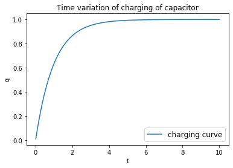

```python
import matplotlib.pyplot as plt
def f(t,q):
    return (E-q/C)/R
R,C,E=1,1,1
t,q,h=0,0,0.01
T,Q=[],[]
n=0
while n<=1000:
    q+=h*f(t,q)
    t+=h
    T.append(t)
    Q.append(q)
    n+=1
plt.plot(T,Q,label='charging curve')
plt.legend(loc='best',prop={'size':12})
plt.xlabel('t')
plt.ylabel('q')
plt.title('Time variation of charging of capacitor')
plt.show()
```

### 3.a) Write a computer program to generate an ellipse and plot it using Matplotlib module.

[Download this program](https://gribja.github.io/c5pQ2018/q3a.py)

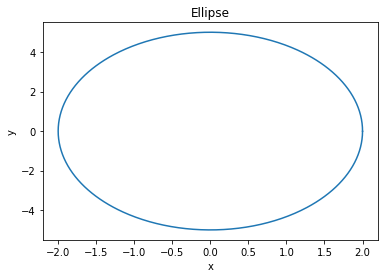

```python
import numpy as np
import matplotlib.pyplot as plt
theta=np.arange(0,2*np.pi,0.01)
a,b=2,5
x,y=a*np.cos(theta),b*np.sin(theta)
plt.plot(x,y)
plt.xlabel('x')
plt.ylabel('y')
plt.title('Ellipse')
plt.show()
```

### 3.b) Write a computer program to solve the differential equation for finding the current in LC circuit connected with DC source using RK2 method and plot it using Matplotlib module.

[Download this program](https://gribja.github.io/c5pQ2018/q3b.py)

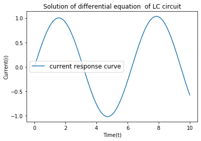

```python
import matplotlib.pyplot as plt
def f(t,q,i):
    return i
def g(t,q,i):
    return (E-q/C)/L
E,L,C=1,1,1
t,q,i=0,0,0
h=0.01
T,Q,I=[],[],[]
n=0
while n<=1000:
    a1=h*f(t,q,i)
    a2=h*f(t+h,q+a1,i+a1)
    b1=h*g(t,q,i)
    b2=h*g(t+h,q+b1,i+b1)
    q+=0.5*(a1+a2)
    i+=0.5*(b1+b2)
    t+=h
    T.append(t)
    Q.append(q)
    I.append(i)
    n+=1
plt.plot(T,I,label='current response curve')
plt.legend(loc='best',prop={'size':12})
plt.xlabel('Time(t)')
plt.ylabel('Current(i)')
plt.title('Solution of differential equation  of LC circuit')
plt.show()
```

### 4.a) Write a computer program to find the transpose of following matrix.

$\begin{pmatrix} 2 & 5 & 12 & 8 \\ 3 & 6 & 9 & 13 \\ 8 & 6 & 4 & 10 \end{pmatrix}$

[Download this program](https://gribja.github.io/c5pQ2018/q4a.py)

```python
import numpy as np
A=np.array([[2,5,12,8],[3,6,9,13],[8,6,4,10]])
print('The transpose of the given matrix \n%s'%(A.T))
```

```
The transpose of the given matrix
[[ 2  3  8]
 [ 5  6  6]
 [12  9  4]
 [ 8 13 10]]
```

### 4.b) The temparature of a well stirred liquid by the isothermal heating coil is given by the equation : $\frac{d\theta}{dt}=K(100-\theta)$, where K is a constant of the system.

### Write a computer program to solve the equation by Runge-Kutta 2nd order method to find q at t = 2.0sec for K=2.5. Initial condition: $\theta=90°C$ at t = 0sec

[Download this program](https://gribja.github.io/c5pQ2018/q4b.py)

```python
def f(t,theta):
    return K*(100-theta)
theta,K,n,h=90,2.5,0,0.01
t,t_final=0,2.0
while n<=t_final:
    k1=h*f(t,theta)
    k2=h*f(t+h,theta+k1)
    theta+=0.5*(k1+k2)
    t+=h
    n+=0.01
print('The value of q at t=2.0 sec is %.3f unit'%(theta/t))
```

[output not shown]

### 5.a) Write a computer program to generate an parabola and plot it using Matplotlib module.

[Download this program](https://gribja.github.io/c5pQ2018/q5a.py)

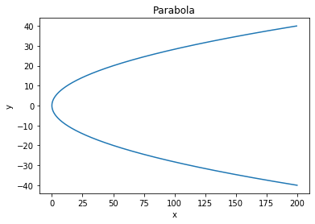

```python
import numpy as np
import matplotlib.pyplot as plt
t=np.arange(-10,10,0.01)
a=2
x,y=a*t**2,2*a*t
plt.plot(x,y)
plt.xlabel('x')
plt.ylabel('y')
plt.title('Parabola')
plt.show()
```

### 5.b) Write a computer program to solve the differential equation for finding the time variation charge during discharging of a capacitor with DC source using Euler and plot it using Matplotlib module.

[Download this program](https://gribja.github.io/c5pQ2018/q5b.py)

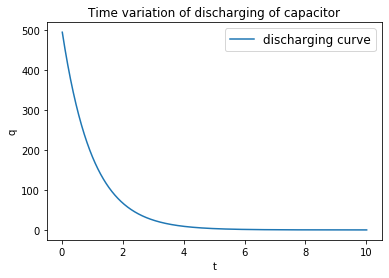

```python
import matplotlib.pyplot as plt
def f(t,q):
    return -q/(C*R)
R,C=1,1
t,q,h=0,500,0.01
T,Q=[],[]
n=0
while n<=1000:
    q+=h*f(t,q)
    t+=h
    T.append(t)
    Q.append(q)
    n+=1
plt.plot(T,Q,label='discharging curve')
plt.legend(loc='best',prop={'size':12})
plt.xlabel('t')
plt.ylabel('q')
plt.title('Time variation of discharging of capacitor')
plt.show()
```

### 6.a) Write a program to find the solution of three given linear system of equations.

$3X_1+2X_2+4X_3=7$,

$2X_1+X_2+X_3=4$,

$X_1+3X_2+5X_3=2$

[Download this program](https://gribja.github.io/c5pQ2018/q6a.py)

```python
import numpy as np
a=np.array([[3,2,4],[2,1,1],[1,3,5]])
b=np.array([7,4,2])
I=np.linalg.solve(a,b)
print('X1=%.3f'%I[0])
print('X2=%.3f'%I[1])
print('x3=%.3f'%I[2])
```

```
X1=2.250
X2=-1.125
x3=0.625
```

[Download this program](https://gribja.github.io/c5pQ2018/q6b.py)

[figure not shown]

```python
import matplotlib.pyplot as plt
def f(t,x,v):
    return v
def g(t,x,v):
    return -w*x-b*v
t,x,v,h=0,1,0,0.01
w,b=1,1.0
T,V,A=[],[],[]
n=0
while n<=1000:
    a1=h*f(t,x,v)
    a2=h*f(t+h,x+a1,v+a1)
    b1=h*g(t,x,v)
    b2=h*g(t+h,x+b1,v+b1)
    x+=0.5*(a1+a2)
    v+=0.5*(b1+b2)
    t+=h
    T.append(t)
    V.append(x)
    A.append(v)
    n+=1
plt.plot(T,A,label='for $b=0.1,\omega_0=1$')
plt.legend(loc='best',prop={'size':12})
plt.xlabel('Time(t)')
plt.ylabel('Position(x)')
plt.title('Motion of Damped Harmonic Oscillator')
plt.show()
```

### 7.a) Write a program to find the solution of three mesh equations of electrical circuit.

$50I_1-30I_3=80$

$40I_2-20I_3=80$

$100I_3-20I_2-30I_1=0$

[Download this program](https://gribja.github.io/c5pQ2018/q7a.py)

```python
import numpy as np
a=np.array([[50,0,-30],[0,40,-20],[-30,-20,100]])
b=np.array([80,80,0])
I=np.linalg.solve(a,b)
print('I1=%.3f'%I[0])
print('I2=%.3f'%I[1])
print('I3=%.3f'%I[2])
```

```
I1=2.333
I2=2.611
I3=1.222
```

### 7.b) Write a computer program to find the solution of a simple harmonic oscillator (no friction) using RK2 method, given $k=1$ and plot it using matplotlib module.

[Download this program](https://gribja.github.io/c5pQ2018/q7b.py)

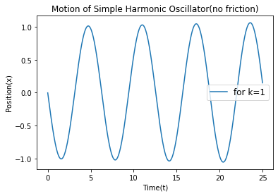

```python
import numpy as np
import matplotlib.pyplot as plt
def f(t,x,dxdt):
    return -k*x
t,x,dxdt=0,1,0
k=1
t_final,dt=25,0.01
T,V,A=[],[],[]
while t<=t_final:
    a1=dt*dxdt
    b1=dt*f(t,x,dxdt)
    a2=dt*(dxdt+0.5*b1)
    b2=dt*f(t+0.5*dt,x+0.5*a1,dxdt+0.5*b1)
    dx=0.5*(a1+a2)
    x+=dx
    dxdt+=0.5*(b1+b2)
    d2xdt2=dx/dt
    T.append(t)
    V.append(dxdt)
    A.append(d2xdt2)
    t+=dt
plt.plot(T,A,label='for k=1')
plt.legend(loc='best',prop={'size':12})
plt.xlabel('Time(t)')
plt.ylabel('Position(x)')
plt.title('Motion of Simple Harmonic Oscillator(no friction)')
plt.show()
```

### 8) Solve the ODE problem

$\frac{dT}{dt}=-\frac{1}{27}(T-65),T(0)=200°F$

[Download this program](https://gribja.github.io/c5pQ2018/q8.py)

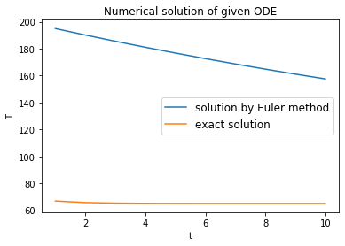

```python
import matplotlib.pyplot as plt
from math import exp
def f(t,T):
    return -(T-65)/27
def g(t):
    return 65+(135*exp(-t))/27

t,T,h=0,200,1.0
time,temp,ex_temp=[],[],[]
n=0
while n<10:
    T+=h*f(t,T)
    t+=h
    time.append(t)
    temp.append(T)
    ex_temp.append(g(t))
    n+=h
plt.plot(time,temp,label='solution by Euler method')
plt.plot(time,ex_temp,label='exact solution')
plt.legend(loc='best',prop={'size':12})
plt.xlabel('t')
plt.ylabel('T')
plt.title('Numerical solution of given ODE')
plt.show()
```

### Fit a straight line $w=kx$ (Hooke's law formula) and plot your fitted graph on the curve with the data.

[Download this program](https://gribja.github.io/c5pQ2018/q9.py)

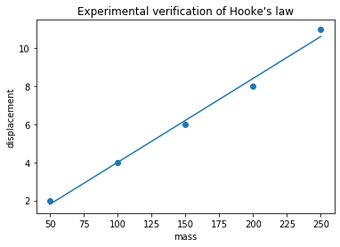

```python
import numpy as np
import matplotlib.pyplot as plt
m=np.array([50,100,150,200,250])
x=np.array([2,4,6,8,11])
coeffs=np.polynomial.polynomial.polyfit(m,x,1)
y=coeffs[1]*m+coeffs[0]
plt.scatter(m,x,label='data points')
plt.plot(m,y,label='best fitted line')
plt.xlabel('mass')
plt.ylabel('displacement')
plt.title("Experimental verification of Hooke's law")
plt.show()
```

### 10) An electric circuit with a resistor, a capacitor, an inductor and a voltage source can be described by the ODE

$L\frac{dI}{dt}+RI+\frac{\theta}{c}=E(t),\frac{d\theta}{dt}=I$

[Download this program](https://gribja.github.io/c5pQ2018/q10.py)

```python
from math import pi,sqrt,sin
import matplotlib.pyplot as plt
def f(t,theta,i):
    return i
def E(t):
    return 2*sin(w*t)
def g(t,theta,i):
    return (E(t)-R*i-theta/C)/L
R,L,C=0.02,1,0.25
w=sqrt(3.5)
t,theta,i=0,1,1
h=2*pi/60*w
n=0
while n<=1000:
    a1=h*f(t,theta,i)
    a2=h*f(t+h,theta+a1,i+a1)
    b1=h*g(t,theta,i)
    b2=h*g(t+h,theta+b1,i+b1)
    theta+=0.5*(a1+a2)
    i+=0.5*(b1+b2)
    t+=h
    n+=1
print(t,theta,i)
```

```
196.1086353649561 5.395580665489027e+20 -8.01105318006513e+20
```